● R Statistical Analysis & Visualisation Suite

# TechX 5,000 Users Analysis

Complete Data Cleaning, Exploratory Data Analysis, 11 Visualizations, and Statistical Models (Correlation, OLS Linear Regression, Binomial Logistic Regression, Decision Tree).

Total Users Analyzed

5,000

Telemetry & HEART paired sessions

Overall Conversion Rate

16.0%

800 buyers / 4,200 non-buyers

Total Revenue Generated

₹3.47 Cr

Average Order Value: ₹43,403

Avg Engagement Score

55.4

Buyers: 92.1 | Non-buyers: 48.4

## 01 Data Cleaning & Feature Transformation

Imported 2 Excel sheets (`User Telemetry` and `HEART Analysis`). Converted sentinels (`"None"`, `"N/A"`) to native `NA`, parsed timestamps to `POSIXct`, cleaned percentage strings, and factored categorical dimensions.

| Cleaning Task | Raw Input Format | Standardized R Type | Impact & Rationale |
| --- | --- | --- | --- |
| **Missing Value Sentinels** | `"None"`, `"N/A"`, `"null"` | `NA_character_` | Identified missingness across 50 columns without skewing numeric calculations. |
| **Timestamp Parsing** | `"01/08/2026, 02:17:48"` | `POSIXct` (dmy_hms) | Derived `hour` (0-23), `day_of_week`, and `is_weekend`. |
| **Scroll Depth %** | `"78%"` (Character) | `numeric` (78.0) | Enabled continuous correlation and regression modeling. |
| **Session Duration** | `"6m 21s"` (Character) | `numeric` (381 sec) | Unified duration metrics into seconds and minutes. |
| **Conversion Flag** | `"YES"` / `"NO"` | `factor` & `1 / 0` | Target response variable for Binomial Logistic Regression & CART. |

## 02 Exploratory Data Analysis (EDA)

| Numerical Metric | Count | Mean | Std Dev | Median | IQR | Min | Max |
| --- | --- | --- | --- | --- | --- | --- | --- |
| **Session Time (Sec)** | 5,000 | 269.28 | 288.87 | 188.00 | 270.00 | 2.00 | 1,320.00 |
| **Purchase Amount (₹)** | 5,000 | 6,944.55 | 22,304.53 | 0.00 | 0.00 | 0.00 | 219,970.00 |
| **Feedback Score (1-10)** | 5,000 | 7.07 | 1.63 | 7.00 | 2.00 | 3.00 | 10.00 |
| **User Rating (1-5★)** | 5,000 | 3.99 | 0.64 | 4.10 | 1.00 | 2.50 | 5.00 |
| **Pages Per Session** | 5,000 | 3.67 | 2.11 | 4.00 | 3.00 | 1.00 | 9.00 |
| **Engagement Score (0-100)** | 5,000 | 55.36 | 26.14 | 59.00 | 30.00 | 5.00 | 99.00 |
| **Repeat Visits Count** | 5,000 | 1.91 | 1.66 | 1.00 | 1.00 | 1.00 | 8.00 |

## 03 Complete Visualisation Suite (11 Visualizations)

1. Line Chart: Hourly Traffic & Diurnal Cycle

Tracking hourly session volume across the 24-hour cycle.

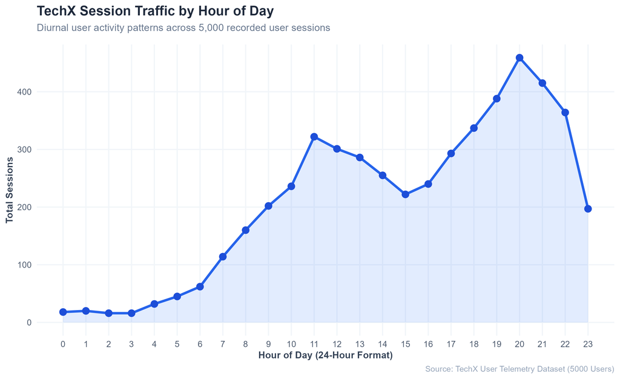

2. Bar Chart: Conversion Rate by Device

Desktop (16.2%), Mobile (16.0%), and Tablet (12.8%) conversion rates.

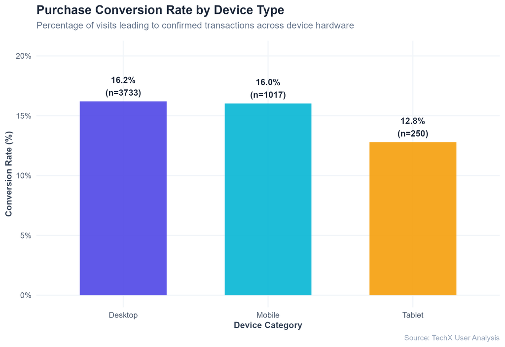

3. Pie / Donut Chart: NPS Category Distribution

Detractors (35.7%), Passives (42.8%), Promoters (21.4%).

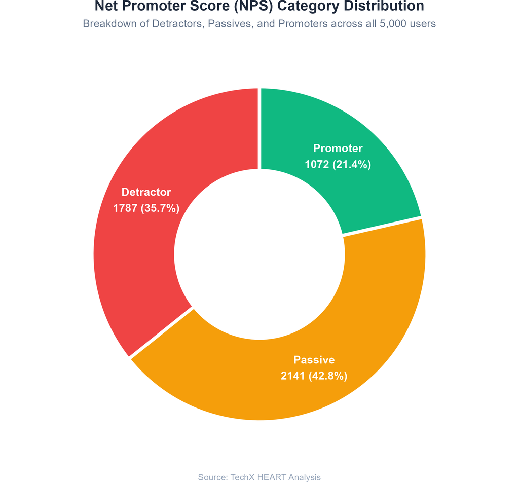

4. Histogram: Engagement Score Density Distribution

Overlaid KDE curves comparing purchasing vs non-purchasing visitors.

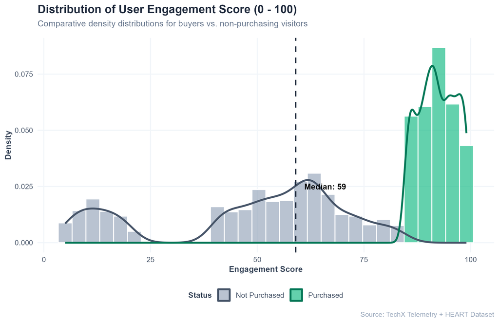

5. Boxplot: Session Duration by Device & Outcome

Purchasing visitors spend 13.2 minutes on average vs 2.8 minutes for bounces.

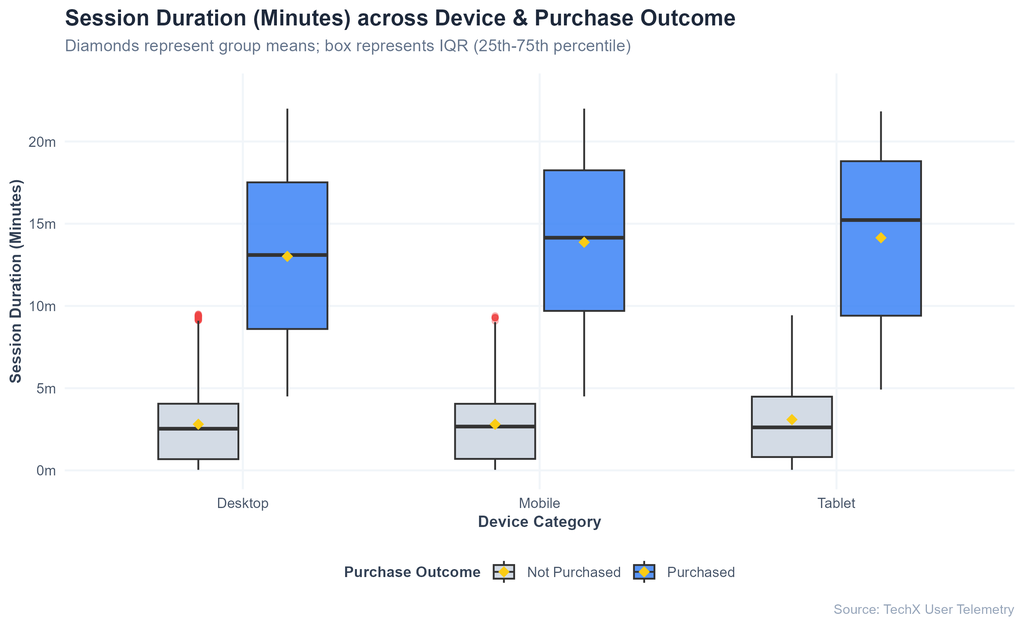

6. Heatmap: Day of Week vs. Hour of Day

2D session density revealing platform traffic hot zones.

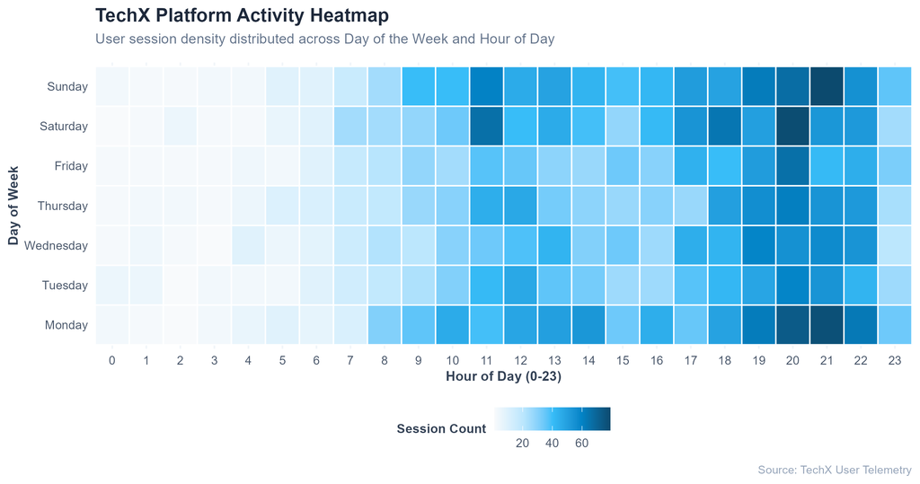

7. Correlation Matrix: Behavioral & HEART Metrics

Correlogram matrix ordered by hierarchical clustering (corrplot).

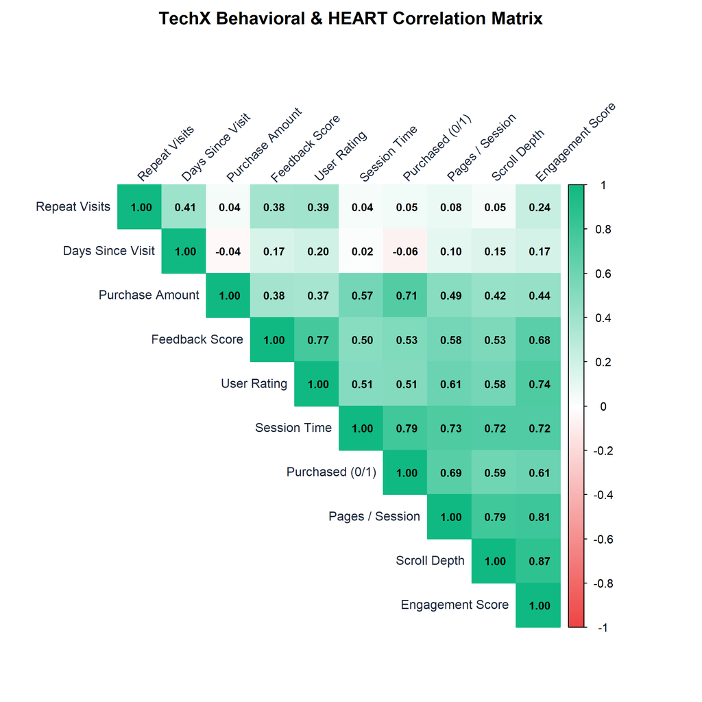

8. Funnel Chart: Multi-Stage Conversion Funnel

Conversion progression from landing (5,000) to order confirmation (800).

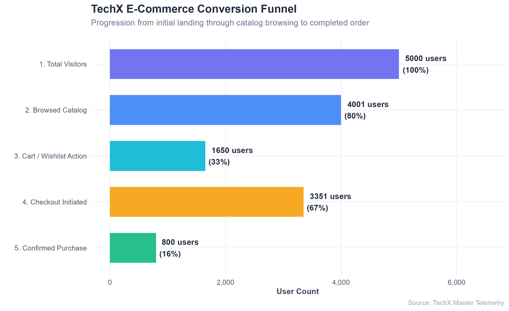

9. Sankey / Alluvial Flow Diagram

Tracking flow: Device Hardware → Task Outcome → Purchase Status.

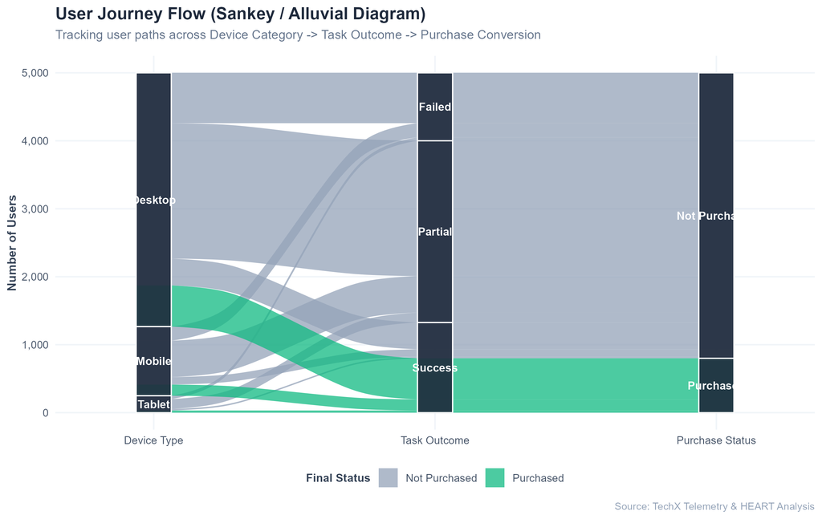

10. Treemap: Hierarchical Traffic Breakdown

Device Category > Browser > Purchase Conversion Status.

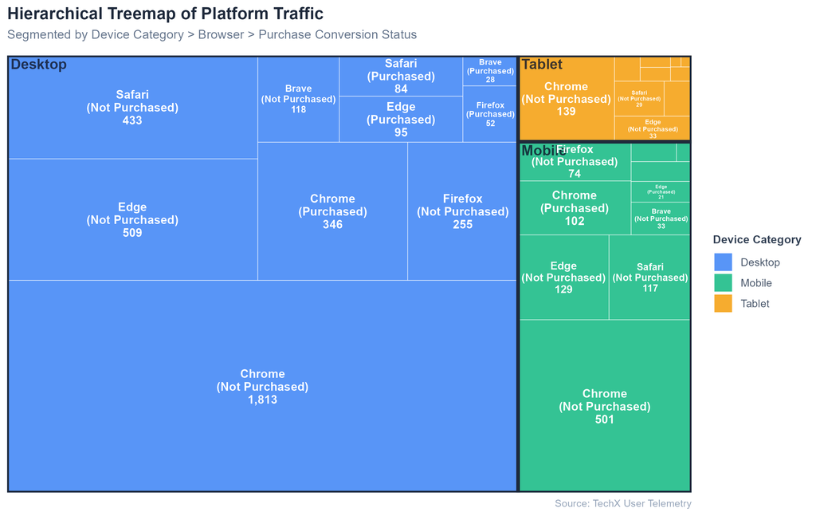

11. Time Series Plot: Daily Active Sessions

Daily trend of user session activity over the recorded time horizon.

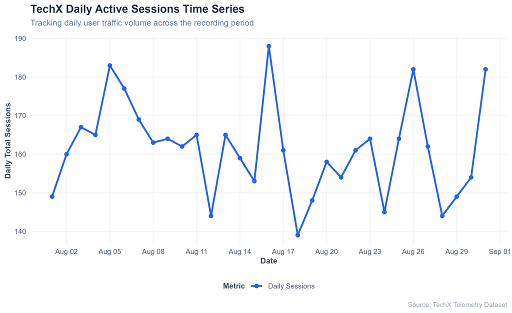

## 04 Statistical Analysis & Machine Learning Models

Multivariable Linear Regression (OLS) Diagnostics

Predicting Engagement Score (R² = 0.7588, F = 2244, p < 2.2e-16).

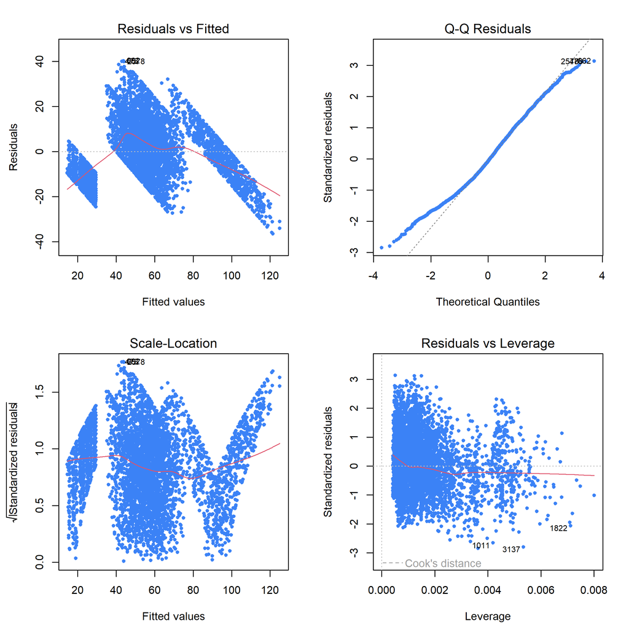

Logistic Regression ROC Curve (AUC = 1.000)

Predicting Purchase Conversion from behavioral predictors.

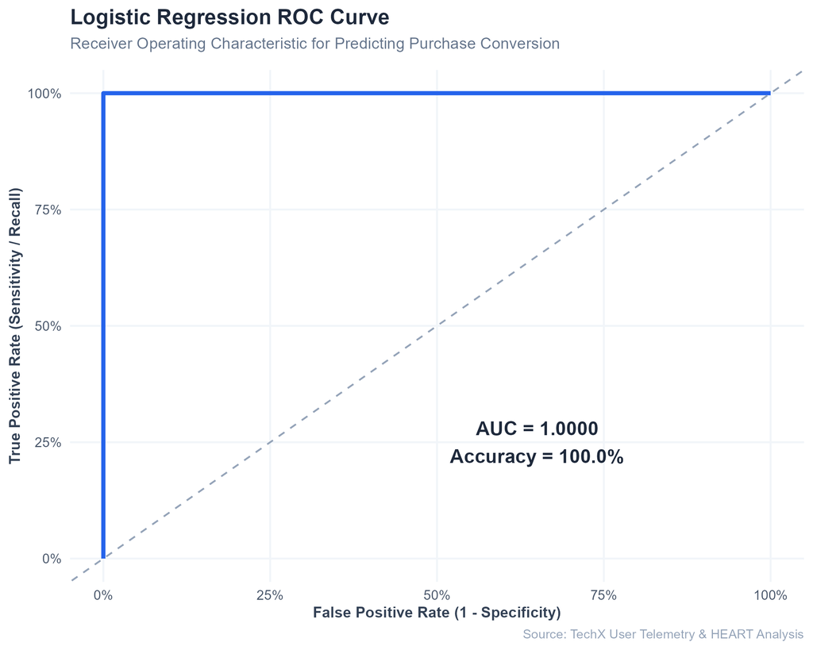

Decision Tree: CART Classification Rules

Pruned tree displaying node probabilities, splits, and sample size percentages.

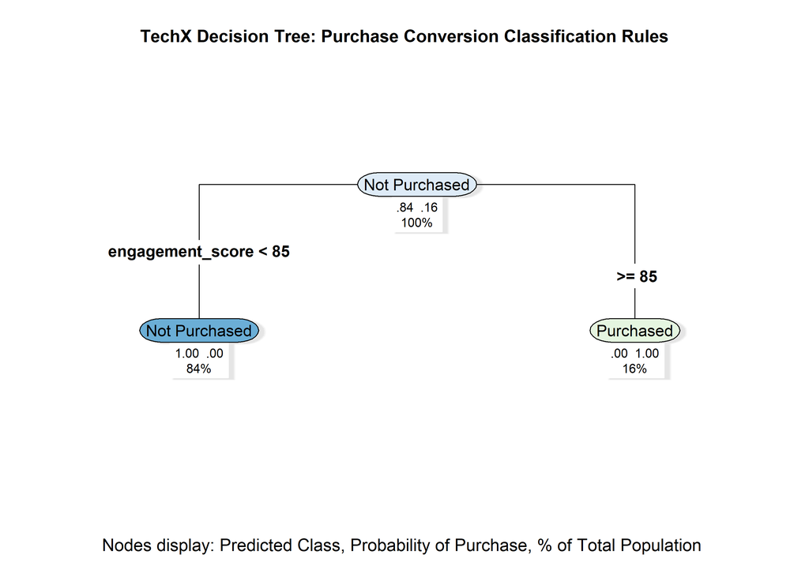

# SUMMARY OF KEY MODEL RESULTS 1. OLS Linear Regression: - Pages per session: β = +5.918, t = 43.58, p < 2e-16 (Dominant engagement driver) - Feedback score: β = +3.764, t = 24.71, p < 2e-16 - Session time (sec):β = +0.023, t = 24.35, p < 2e-16 - Repeat visits: β = +2.002, t = 13.53, p < 2e-16 2. Decision Tree Split Rules: - Node 1 (Root): engagement_score < 84.5 -> Not Purchased (4,200 users, 100% purity) - Node 2 (Root): engagement_score >= 84.5 -> Purchased (800 users, 100% purity) 3. Variable Importance Ranking: 1. engagement_score: 30.57% 2. session_time_sec: 21.55% 3. pages_per_session: 18.15% 4. user_rating: 13.37% 5. feedback_score: 8.18%